# SQ 014

## Shared Qs (014)

#### Question

1. Let functions $f$ and $g$ be defined below:
   $$f(x) = x^3+x^2$$
   $$g(x)=\frac{1}{x}-x$$

   Match the following functions to a composition:

   $$\begin{align}
   a(x) &= \left(\frac{1}{x}-x\right)^3+\left(\frac{1}{x}-x\right)^2 \\\\
   b(x) &= \frac{1}{\left(\frac{1}{x}-x\right)}-\left(\frac{1}{x}-x\right) \\\\
   c(x) &= \frac{1}{\left(x^3+x^2\right)}-\left(x^3+x^2\right) \\\\
   d(x) &= \left(x^3+x^2\right)^3+\left(x^3+x^2\right)^2
   \end{align}$$

   *Your answers here:*
   - Match from above: $f(g(x)) =$
   - Match from above: $g(f(x)) =$
   - Match from above: $f(f(x)) =$
   - Match from above: $g(g(x)) =$

#### Solution

#### Question

2. Let functions $f$ and $g$ be defined below:
   $$f(x) = \sqrt{x}-\frac{1}{x}$$
   $$g(x)=\frac{x+1}{2-x}$$

   Match the following functions to a composition:

   $$\begin{align}
   a(x) &= \sqrt{\left(\frac{x+1}{2-x}\right)}-\frac{1}{\left(\frac{x+1}{2-x}\right)} \\\\
   b(x) &= \sqrt{\left(\sqrt{x}-\frac{1}{x}\right)}-\frac{1}{\left(\sqrt{x}-\frac{1}{x}\right)} \\\\
   c(x) &= \frac{\left(\sqrt{x}-\frac{1}{x}\right)+1}{2-\left(\sqrt{x}-\frac{1}{x}\right)} \\\\
   d(x) &= \frac{\left(\frac{x+1}{2-x}\right)+1}{2-\left(\frac{x+1}{2-x}\right)}
   \end{align}$$

   *Your answers here:*
   - Match from above: $f(g(x)) =$
   - Match from above: $g(f(x)) =$
   - Match from above: $f(f(x)) =$
   - Match from above: $g(g(x)) =$

#### Solution

#### Question

3. Let functions $f$ and $g$ be defined below:
   $$f(x) = x^2+\frac{1}{x^2}$$
   $$g(x)=\ln\left(x\right)+\frac{1}{x}$$

   Match the following functions to a composition:

   $$\begin{align}
   a(x) &= \left(\ln\left(x\right)+\frac{1}{x}\right)^2+\frac{1}{\left(\ln\left(x\right)+\frac{1}{x}\right)^2} \\\\
   b(x) &= \ln\left(\left(x^2+\frac{1}{x^2}\right)\right)+\frac{1}{\left(x^2+\frac{1}{x^2}\right)} \\\\
   c(x) &= \left(x^2+\frac{1}{x^2}\right)^2+\frac{1}{\left(x^2+\frac{1}{x^2}\right)^2} \\\\
   d(x) &= \ln\left(\left(\ln\left(x\right)+\frac{1}{x}\right)\right)+\frac{1}{\left(\ln\left(x\right)+\frac{1}{x}\right)}
   \end{align}$$

   *Your answers here:*
   - Match from above: $f(g(x)) =$
   - Match from above: $g(f(x)) =$
   - Match from above: $f(f(x)) =$
   - Match from above: $g(g(x)) =$

#### Solution

#### Question

4. Let functions $f$ and $g$ be defined below:
   $$f(x) = \sqrt{x}-\frac{1}{x}$$
   $$g(x)=3x-x^2$$

   Match the following functions to a composition:

   $$\begin{align}
   a(x) &= \sqrt{\left(3x-x^2\right)}-\frac{1}{\left(3x-x^2\right)} \\\\
   b(x) &= 3\left(3x-x^2\right)-\left(3x-x^2\right)^2 \\\\
   c(x) &= \sqrt{\left(\sqrt{x}-\frac{1}{x}\right)}-\frac{1}{\left(\sqrt{x}-\frac{1}{x}\right)} \\\\
   d(x) &= 3\left(\sqrt{x}-\frac{1}{x}\right)-\left(\sqrt{x}-\frac{1}{x}\right)^2
   \end{align}$$

   *Your answers here:*
   - Match from above: $f(g(x)) =$
   - Match from above: $g(f(x)) =$
   - Match from above: $f(f(x)) =$
   - Match from above: $g(g(x)) =$

#### Solution

#### Question

5. Let functions $f$ and $g$ be defined below:
   $$f(x) = \frac{1}{x}-x$$
   $$g(x)=\left|x+1\right|+x!$$

   Match the following functions to a composition:

   $$\begin{align}
   a(x) &= \left|\left(\left|x+1\right|+x!\right)+1\right|+\left(\left|x+1\right|+x!\right)! \\\\
   b(x) &= \left|\left(\frac{1}{x}-x\right)+1\right|+\left(\frac{1}{x}-x\right)! \\\\
   c(x) &= \frac{1}{\left(\frac{1}{x}-x\right)}-\left(\frac{1}{x}-x\right) \\\\
   d(x) &= \frac{1}{\left(\left|x+1\right|+x!\right)}-\left(\left|x+1\right|+x!\right)
   \end{align}$$

   *Your answers here:*
   - Match from above: $f(g(x)) =$
   - Match from above: $g(f(x)) =$
   - Match from above: $f(f(x)) =$
   - Match from above: $g(g(x)) =$

#### Solution

#### Question

6. Let functions $f$ and $g$ be defined below:
   $$f(x) = 3x-x^2$$
   $$g(x)=\frac{x+1}{2-x}$$

   Match the following functions to a composition:

   $$\begin{align}
   a(x) &= 3\left(\frac{x+1}{2-x}\right)-\left(\frac{x+1}{2-x}\right)^2 \\\\
   b(x) &= \frac{\left(3x-x^2\right)+1}{2-\left(3x-x^2\right)} \\\\
   c(x) &= 3\left(3x-x^2\right)-\left(3x-x^2\right)^2 \\\\
   d(x) &= \frac{\left(\frac{x+1}{2-x}\right)+1}{2-\left(\frac{x+1}{2-x}\right)}
   \end{align}$$

   *Your answers here:*
   - Match from above: $f(g(x)) =$
   - Match from above: $g(f(x)) =$
   - Match from above: $f(f(x)) =$
   - Match from above: $g(g(x)) =$

#### Solution

#### Question

7. Let functions $f$ and $g$ be defined below:
   $$f(x) = \left|x+1\right|+x!$$
   $$g(x)=\left|x\right|+2x^2$$

   Match the following functions to a composition:

   $$\begin{align}
   a(x) &= \left|\left(\left|x+1\right|+x!\right)\right|+2\left(\left|x+1\right|+x!\right)^2 \\\\
   b(x) &= \left|\left(\left|x\right|+2x^2\right)\right|+2\left(\left|x\right|+2x^2\right)^2 \\\\
   c(x) &= \left|\left(\left|x+1\right|+x!\right)+1\right|+\left(\left|x+1\right|+x!\right)! \\\\
   d(x) &= \left|\left(\left|x\right|+2x^2\right)+1\right|+\left(\left|x\right|+2x^2\right)!
   \end{align}$$

   *Your answers here:*
   - Match from above: $f(g(x)) =$
   - Match from above: $g(f(x)) =$
   - Match from above: $f(f(x)) =$
   - Match from above: $g(g(x)) =$

#### Solution

#### Question

8. Let functions $f$ and $g$ be defined below:
   $$f(x) = \frac{1}{x}-x$$
   $$g(x)=x^2+\frac{1}{x^2}$$

   Match the following functions to a composition:

   $$\begin{align}
   a(x) &= \left(\frac{1}{x}-x\right)^2+\frac{1}{\left(\frac{1}{x}-x\right)^2} \\\\
   b(x) &= \left(x^2+\frac{1}{x^2}\right)^2+\frac{1}{\left(x^2+\frac{1}{x^2}\right)^2} \\\\
   c(x) &= \frac{1}{\left(x^2+\frac{1}{x^2}\right)}-\left(x^2+\frac{1}{x^2}\right) \\\\
   d(x) &= \frac{1}{\left(\frac{1}{x}-x\right)}-\left(\frac{1}{x}-x\right)
   \end{align}$$

   *Your answers here:*
   - Match from above: $f(g(x)) =$
   - Match from above: $g(f(x)) =$
   - Match from above: $f(f(x)) =$
   - Match from above: $g(g(x)) =$

#### Solution

#### Question

9. Let functions $f$ and $g$ be defined below:
   $$f(x) = \sin\left(x\right)+\cos\left(x\right)$$
   $$g(x)=x^3+x^2$$

   Match the following functions to a composition:

   $$\begin{align}
   a(x) &= \sin\left(\left(x^3+x^2\right)\right)+\cos\left(\left(x^3+x^2\right)\right) \\\\
   b(x) &= \left(\sin\left(x\right)+\cos\left(x\right)\right)^3+\left(\sin\left(x\right)+\cos\left(x\right)\right)^2 \\\\
   c(x) &= \sin\left(\left(\sin\left(x\right)+\cos\left(x\right)\right)\right)+\cos\left(\left(\sin\left(x\right)+\cos\left(x\right)\right)\right) \\\\
   d(x) &= \left(x^3+x^2\right)^3+\left(x^3+x^2\right)^2
   \end{align}$$

   *Your answers here:*
   - Match from above: $f(g(x)) =$
   - Match from above: $g(f(x)) =$
   - Match from above: $f(f(x)) =$
   - Match from above: $g(g(x)) =$

#### Solution

#### Question

10. Let functions $f$ and $g$ be defined below:
    $$f(x) = \left|x\right|+2x^2$$
    $$g(x)=\sqrt{x}-\frac{1}{x}$$

    Match the following functions to a composition:

    $$\begin{align}
    a(x) &= \sqrt{\left(\sqrt{x}-\frac{1}{x}\right)}-\frac{1}{\left(\sqrt{x}-\frac{1}{x}\right)} \\\\
    b(x) &= \left|\left(\left|x\right|+2x^2\right)\right|+2\left(\left|x\right|+2x^2\right)^2 \\\\
    c(x) &= \sqrt{\left(\left|x\right|+2x^2\right)}-\frac{1}{\left(\left|x\right|+2x^2\right)} \\\\
    d(x) &= \left|\left(\sqrt{x}-\frac{1}{x}\right)\right|+2\left(\sqrt{x}-\frac{1}{x}\right)^2
    \end{align}$$

    *Your answers here:*
    - Match from above: $f(g(x)) =$
    - Match from above: $g(f(x)) =$
    - Match from above: $f(f(x)) =$
    - Match from above: $g(g(x)) =$

#### Solution

#### Question

11. Let function $f$ be defined by the table below.

    | $x$ | $f(x)$ |
    | --- | --- |
    | 1 | 6 |
    | 2 | 1 |
    | 3 | 2 |
    | 4 | 3 |
    | 5 | 4 |
    | 6 | 5 |

    Create the [inverse function’s](https://en.wikipedia.org/wiki/Inverse_function) table. *Your answers here:*

    | $x$ | $f^{-1}(x)$ |
    | --- | --- |
    | 1 |  |
    | 2 |  |
    | 3 |  |
    | 4 |  |
    | 5 |  |
    | 6 |  |

    - Calculate $f(f^{-1}(4))$ =
    - Calculate $f^{-1}(f^{-1}(3))$ =
    - Calculate $f(f(6))$ =
    - Calculate $f^{-1}(f(5))$ =

#### Solution

#### Question

12. Let function $f$ be defined by the table below.

    | $x$ | $f(x)$ |
    | --- | --- |
    | 1 | 2 |
    | 2 | 6 |
    | 3 | 1 |
    | 4 | 3 |
    | 5 | 4 |
    | 6 | 5 |

    Create the [inverse function’s](https://en.wikipedia.org/wiki/Inverse_function) table. *Your answers here:*

    | $x$ | $f^{-1}(x)$ |
    | --- | --- |
    | 1 |  |
    | 2 |  |
    | 3 |  |
    | 4 |  |
    | 5 |  |
    | 6 |  |

    - Calculate $f^{-1}(f(4))$ =
    - Calculate $f^{-1}(f^{-1}(5))$ =
    - Calculate $f(f^{-1}(2))$ =
    - Calculate $f(f(6))$ =

#### Solution

#### Question

13. Let function $f$ be defined by the table below.

    | $x$ | $f(x)$ |
    | --- | --- |
    | 1 | 6 |
    | 2 | 4 |
    | 3 | 5 |
    | 4 | 3 |
    | 5 | 1 |
    | 6 | 2 |

    Create the [inverse function’s](https://en.wikipedia.org/wiki/Inverse_function) table. *Your answers here:*

    | $x$ | $f^{-1}(x)$ |
    | --- | --- |
    | 1 |  |
    | 2 |  |
    | 3 |  |
    | 4 |  |
    | 5 |  |
    | 6 |  |

    - Calculate $f^{-1}(f^{-1}(2))$ =
    - Calculate $f^{-1}(f(3))$ =
    - Calculate $f(f(1))$ =
    - Calculate $f(f^{-1}(5))$ =

#### Solution

#### Question

14. Let function $f$ be defined by the table below.

    | $x$ | $f(x)$ |
    | --- | --- |
    | 1 | 4 |
    | 2 | 1 |
    | 3 | 5 |
    | 4 | 6 |
    | 5 | 2 |
    | 6 | 3 |

    Create the [inverse function’s](https://en.wikipedia.org/wiki/Inverse_function) table. *Your answers here:*

    | $x$ | $f^{-1}(x)$ |
    | --- | --- |
    | 1 |  |
    | 2 |  |
    | 3 |  |
    | 4 |  |
    | 5 |  |
    | 6 |  |

    - Calculate $f(f^{-1}(5))$ =
    - Calculate $f^{-1}(f(1))$ =
    - Calculate $f^{-1}(f^{-1}(4))$ =
    - Calculate $f(f(3))$ =

#### Solution

#### Question

15. Let function $f$ be defined by the table below.

    | $x$ | $f(x)$ |
    | --- | --- |
    | 1 | 6 |
    | 2 | 4 |
    | 3 | 1 |
    | 4 | 3 |
    | 5 | 2 |
    | 6 | 5 |

    Create the [inverse function’s](https://en.wikipedia.org/wiki/Inverse_function) table. *Your answers here:*

    | $x$ | $f^{-1}(x)$ |
    | --- | --- |
    | 1 |  |
    | 2 |  |
    | 3 |  |
    | 4 |  |
    | 5 |  |
    | 6 |  |

    - Calculate $f(f^{-1}(5))$ =
    - Calculate $f^{-1}(f(2))$ =
    - Calculate $f^{-1}(f^{-1}(3))$ =
    - Calculate $f(f(1))$ =

#### Solution

#### Question

16. Let function $f$ be defined by the table below.

    | $x$ | $f(x)$ |
    | --- | --- |
    | 1 | 2 |
    | 2 | 5 |
    | 3 | 1 |
    | 4 | 6 |
    | 5 | 4 |
    | 6 | 3 |

    Create the [inverse function’s](https://en.wikipedia.org/wiki/Inverse_function) table. *Your answers here:*

    | $x$ | $f^{-1}(x)$ |
    | --- | --- |
    | 1 |  |
    | 2 |  |
    | 3 |  |
    | 4 |  |
    | 5 |  |
    | 6 |  |

    - Calculate $f(f^{-1}(6))$ =
    - Calculate $f(f(2))$ =
    - Calculate $f^{-1}(f(5))$ =
    - Calculate $f^{-1}(f^{-1}(1))$ =

#### Solution

#### Question

17. Let function $f$ be defined by the table below.

    | $x$ | $f(x)$ |
    | --- | --- |
    | 1 | 5 |
    | 2 | 3 |
    | 3 | 1 |
    | 4 | 2 |
    | 5 | 6 |
    | 6 | 4 |

    Create the [inverse function’s](https://en.wikipedia.org/wiki/Inverse_function) table. *Your answers here:*

    | $x$ | $f^{-1}(x)$ |
    | --- | --- |
    | 1 |  |
    | 2 |  |
    | 3 |  |
    | 4 |  |
    | 5 |  |
    | 6 |  |

    - Calculate $f^{-1}(f^{-1}(5))$ =
    - Calculate $f(f(2))$ =
    - Calculate $f^{-1}(f(1))$ =
    - Calculate $f(f^{-1}(4))$ =

#### Solution

#### Question

18. Let function $f$ be defined by the table below.

    | $x$ | $f(x)$ |
    | --- | --- |
    | 1 | 3 |
    | 2 | 5 |
    | 3 | 6 |
    | 4 | 1 |
    | 5 | 4 |
    | 6 | 2 |

    Create the [inverse function’s](https://en.wikipedia.org/wiki/Inverse_function) table. *Your answers here:*

    | $x$ | $f^{-1}(x)$ |
    | --- | --- |
    | 1 |  |
    | 2 |  |
    | 3 |  |
    | 4 |  |
    | 5 |  |
    | 6 |  |

    - Calculate $f^{-1}(f^{-1}(3))$ =
    - Calculate $f(f(4))$ =
    - Calculate $f^{-1}(f(6))$ =
    - Calculate $f(f^{-1}(2))$ =

#### Solution

#### Question

19. Let function $f$ be defined by the table below.

    | $x$ | $f(x)$ |
    | --- | --- |
    | 1 | 2 |
    | 2 | 5 |
    | 3 | 6 |
    | 4 | 3 |
    | 5 | 1 |
    | 6 | 4 |

    Create the [inverse function’s](https://en.wikipedia.org/wiki/Inverse_function) table. *Your answers here:*

    | $x$ | $f^{-1}(x)$ |
    | --- | --- |
    | 1 |  |
    | 2 |  |
    | 3 |  |
    | 4 |  |
    | 5 |  |
    | 6 |  |

    - Calculate $f^{-1}(f^{-1}(6))$ =
    - Calculate $f(f(5))$ =
    - Calculate $f(f^{-1}(2))$ =
    - Calculate $f^{-1}(f(3))$ =

#### Solution

#### Question

20. Let function $f$ be defined by the table below.

    | $x$ | $f(x)$ |
    | --- | --- |
    | 1 | 3 |
    | 2 | 5 |
    | 3 | 6 |
    | 4 | 2 |
    | 5 | 1 |
    | 6 | 4 |

    Create the [inverse function’s](https://en.wikipedia.org/wiki/Inverse_function) table. *Your answers here:*

    | $x$ | $f^{-1}(x)$ |
    | --- | --- |
    | 1 |  |
    | 2 |  |
    | 3 |  |
    | 4 |  |
    | 5 |  |
    | 6 |  |

    - Calculate $f(f^{-1}(5))$ =
    - Calculate $f^{-1}(f(1))$ =
    - Calculate $f^{-1}(f^{-1}(3))$ =
    - Calculate $f(f(4))$ =

#### Solution

#### Question

21. Let function $f$ be defined with the algebraic formula below:
    $$f(x) = \frac{x}{3}+7$$

    Find an expression for the inverse function $f^{-1}$.
    1. $f^{-1}(x)~=~3(x-7)$
    2. $f^{-1}(x)~=~\frac{x+7}{3}$
    3. $f^{-1}(x)~=~3(x+7)$
    4. $f^{-1}(x)~=~7x-3$

#### Solution

#### Question

22. Let function $f$ be defined with the algebraic formula below:
    $$f(x) = 3(x-7)$$

    Find an expression for the inverse function $f^{-1}$.
    1. $f^{-1}(x)~=~\frac{x-3}{7}$
    2. $f^{-1}(x)~=~\frac{x}{3}+7$
    3. $f^{-1}(x)~=~3x-7$
    4. $f^{-1}(x)~=~7(x-3)$

#### Solution

#### Question

23. Let function $f$ be defined with the algebraic formula below:
    $$f(x) = 5x+6$$

    Find an expression for the inverse function $f^{-1}$.
    1. $f^{-1}(x)~=~5(x-6)$
    2. $f^{-1}(x)~=~\frac{x-6}{5}$
    3. $f^{-1}(x)~=~5(x+6)$
    4. $f^{-1}(x)~=~\frac{x}{6}+5$

#### Solution

#### Question

24. Let function $f$ be defined with the algebraic formula below:
    $$f(x) = \frac{x}{7}+8$$

    Find an expression for the inverse function $f^{-1}$.
    1. $f^{-1}(x)~=~8x-7$
    2. $f^{-1}(x)~=~\frac{x-8}{7}$
    3. $f^{-1}(x)~=~\frac{x}{8}-7$
    4. $f^{-1}(x)~=~7(x-8)$

#### Solution

#### Question

25. Let function $f$ be defined with the algebraic formula below:
    $$f(x) = 5x-9$$

    Find an expression for the inverse function $f^{-1}$.
    1. $f^{-1}(x)~=~9x+5$
    2. $f^{-1}(x)~=~5(x-9)$
    3. $f^{-1}(x)~=~\frac{x+9}{5}$
    4. $f^{-1}(x)~=~\frac{x}{9}-5$

#### Solution

#### Question

26. Let function $f$ be defined with the algebraic formula below:
    $$f(x) = 6(x-9)$$

    Find an expression for the inverse function $f^{-1}$.
    1. $f^{-1}(x)~=~\frac{x}{6}+9$
    2. $f^{-1}(x)~=~6x+9$
    3. $f^{-1}(x)~=~9(x+6)$
    4. $f^{-1}(x)~=~\frac{x-6}{9}$

#### Solution

#### Question

27. Let function $f$ be defined with the algebraic formula below:
    $$f(x) = 4x+7$$

    Find an expression for the inverse function $f^{-1}$.
    1. $f^{-1}(x)~=~7x+4$
    2. $f^{-1}(x)~=~\frac{x-7}{4}$
    3. $f^{-1}(x)~=~\frac{x+7}{4}$
    4. $f^{-1}(x)~=~7x-4$

#### Solution

#### Question

28. Let function $f$ be defined with the algebraic formula below:
    $$f(x) = \frac{x+5}{4}$$

    Find an expression for the inverse function $f^{-1}$.
    1. $f^{-1}(x)~=~\frac{x-4}{5}$
    2. $f^{-1}(x)~=~4x-5$
    3. $f^{-1}(x)~=~\frac{x+4}{5}$
    4. $f^{-1}(x)~=~4x+5$

#### Solution

#### Question

29. Let function $f$ be defined with the algebraic formula below:
    $$f(x) = 4x+3$$

    Find an expression for the inverse function $f^{-1}$.
    1. $f^{-1}(x)~=~\frac{x-3}{4}$
    2. $f^{-1}(x)~=~\frac{x}{3}+4$
    3. $f^{-1}(x)~=~4(x-3)$
    4. $f^{-1}(x)~=~\frac{x+3}{4}$

#### Solution

#### Question

30. Let function $f$ be defined with the algebraic formula below:
    $$f(x) = \frac{x}{9}+7$$

    Find an expression for the inverse function $f^{-1}$.
    1. $f^{-1}(x)~=~\frac{x}{7}-9$
    2. $f^{-1}(x)~=~\frac{x-7}{9}$
    3. $f^{-1}(x)~=~9(x-7)$
    4. $f^{-1}(x)~=~7x-9$

#### Solution

#### Question

31. Let function $f$ be defined with the algebraic formula below:
    $$f(x) = \frac{3x+4}{-7x+8}$$

    The inverse function $f^{-1}$ can be expressed as:

    $$f^{-1}(x) = \frac{ax+b}{cx+d}$$

    Find the integer values for $a$, $b$, $c$, and $d$.
    - $a=$
    - $b=$
    - $c=$
    - $d=$

#### Solution

#### Question

32. Let function $f$ be defined with the algebraic formula below:
    $$f(x) = \frac{-4x+3}{-6x+7}$$

    The inverse function $f^{-1}$ can be expressed as:

    $$f^{-1}(x) = \frac{ax+b}{cx+d}$$

    Find the integer values for $a$, $b$, $c$, and $d$.
    - $a=$
    - $b=$
    - $c=$
    - $d=$

#### Solution

#### Question

33. Let function $f$ be defined with the algebraic formula below:
    $$f(x) = \frac{8x+7}{-4x+6}$$

    The inverse function $f^{-1}$ can be expressed as:

    $$f^{-1}(x) = \frac{ax+b}{cx+d}$$

    Find the integer values for $a$, $b$, $c$, and $d$.
    - $a=$
    - $b=$
    - $c=$
    - $d=$

#### Solution

#### Question

34. Let function $f$ be defined with the algebraic formula below:
    $$f(x) = \frac{6x+5}{-4x-7}$$

    The inverse function $f^{-1}$ can be expressed as:

    $$f^{-1}(x) = \frac{ax+b}{cx+d}$$

    Find the integer values for $a$, $b$, $c$, and $d$.
    - $a=$
    - $b=$
    - $c=$
    - $d=$

#### Solution

#### Question

35. Let function $f$ be defined with the algebraic formula below:
    $$f(x) = \frac{5x+8}{-6x+9}$$

    The inverse function $f^{-1}$ can be expressed as:

    $$f^{-1}(x) = \frac{ax+b}{cx+d}$$

    Find the integer values for $a$, $b$, $c$, and $d$.
    - $a=$
    - $b=$
    - $c=$
    - $d=$

#### Solution

#### Question

36. Let function $f$ be defined with the algebraic formula below:
    $$f(x) = \frac{-9x-5}{7x+4}$$

    The inverse function $f^{-1}$ can be expressed as:

    $$f^{-1}(x) = \frac{ax+b}{cx+d}$$

    Find the integer values for $a$, $b$, $c$, and $d$.
    - $a=$
    - $b=$
    - $c=$
    - $d=$

#### Solution

#### Question

37. Let function $f$ be defined with the algebraic formula below:
    $$f(x) = \frac{4x-7}{-9x+8}$$

    The inverse function $f^{-1}$ can be expressed as:

    $$f^{-1}(x) = \frac{ax+b}{cx+d}$$

    Find the integer values for $a$, $b$, $c$, and $d$.
    - $a=$
    - $b=$
    - $c=$
    - $d=$

#### Solution

#### Question

38. Let function $f$ be defined with the algebraic formula below:
    $$f(x) = \frac{-9x-6}{5x-7}$$

    The inverse function $f^{-1}$ can be expressed as:

    $$f^{-1}(x) = \frac{ax+b}{cx+d}$$

    Find the integer values for $a$, $b$, $c$, and $d$.
    - $a=$
    - $b=$
    - $c=$
    - $d=$

#### Solution

#### Question

39. Let function $f$ be defined with the algebraic formula below:
    $$f(x) = \frac{7x-5}{8x+9}$$

    The inverse function $f^{-1}$ can be expressed as:

    $$f^{-1}(x) = \frac{ax+b}{cx+d}$$

    Find the integer values for $a$, $b$, $c$, and $d$.
    - $a=$
    - $b=$
    - $c=$
    - $d=$

#### Solution

#### Question

40. Let function $f$ be defined with the algebraic formula below:
    $$f(x) = \frac{-9x-3}{6x-8}$$

    The inverse function $f^{-1}$ can be expressed as:

    $$f^{-1}(x) = \frac{ax+b}{cx+d}$$

    Find the integer values for $a$, $b$, $c$, and $d$.
    - $a=$
    - $b=$
    - $c=$
    - $d=$

#### Solution

#### Question

41. The [one-to-one](https://en.wikipedia.org/wiki/Injective_function) function $f$ is plotted below:

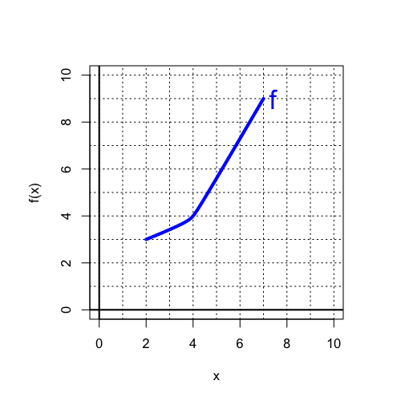

    Which of the following red curves is a graph of the inverse function, $f^{-1}$?
    - A

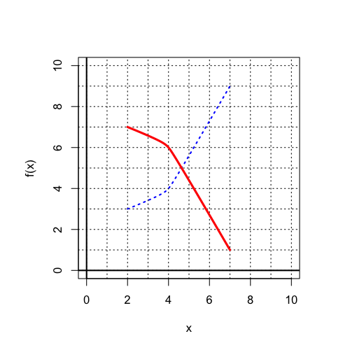

    - B

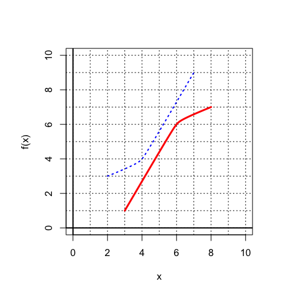

    - C

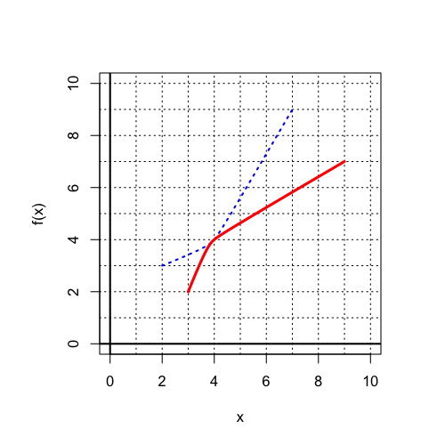

    - D

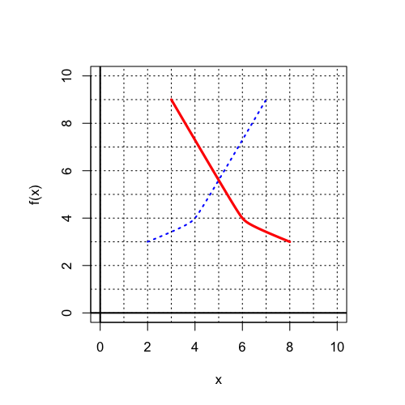

    1. A
    2. B
    3. C
    4. D

#### Solution

#### Question

42. The [one-to-one](https://en.wikipedia.org/wiki/Injective_function) function $f$ is plotted below:

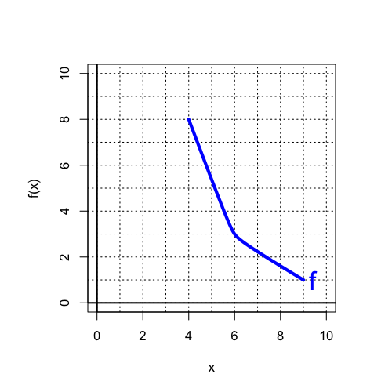

    Which of the following red curves is a graph of the inverse function, $f^{-1}$?
    - A

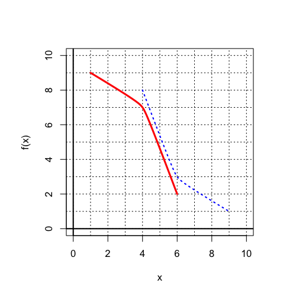

    - B

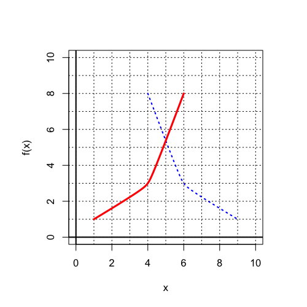

    - C

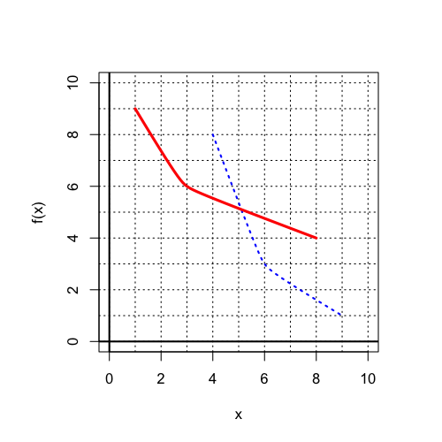

    - D

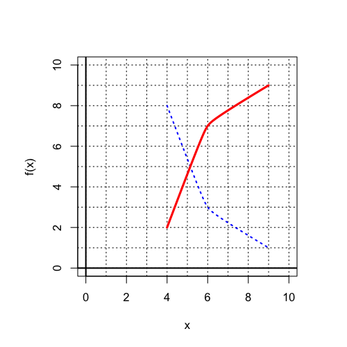

    1. A
    2. B
    3. C
    4. D

#### Solution

#### Question

43. The [one-to-one](https://en.wikipedia.org/wiki/Injective_function) function $f$ is plotted below:

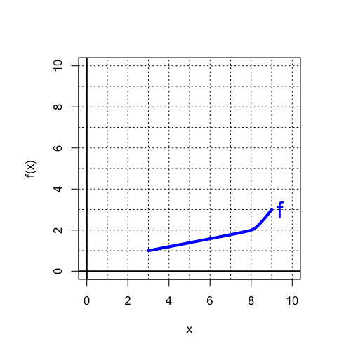

    Which of the following red curves is a graph of the inverse function, $f^{-1}$?
    - A

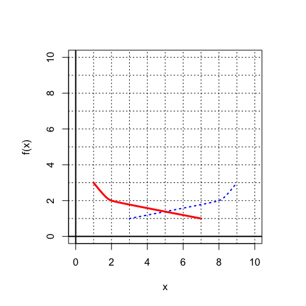

    - B

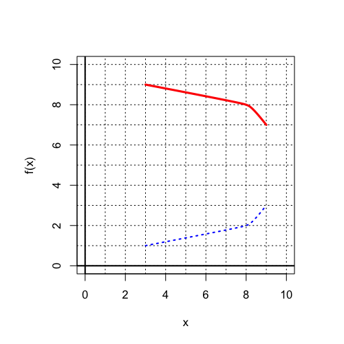

    - C

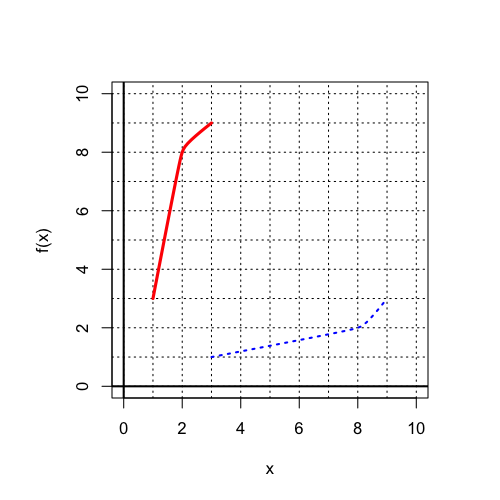

    - D

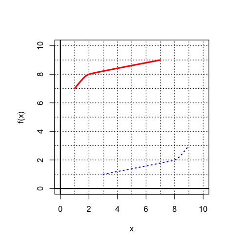

    1. A
    2. B
    3. C
    4. D

#### Solution

#### Question

44. The [one-to-one](https://en.wikipedia.org/wiki/Injective_function) function $f$ is plotted below:

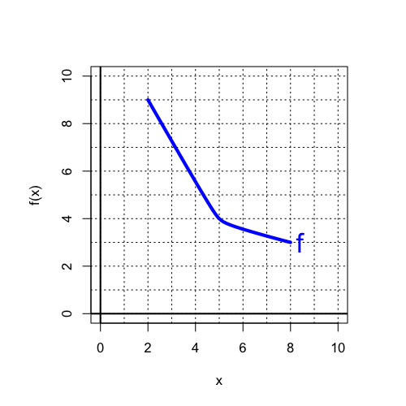

    Which of the following red curves is a graph of the inverse function, $f^{-1}$?
    - A

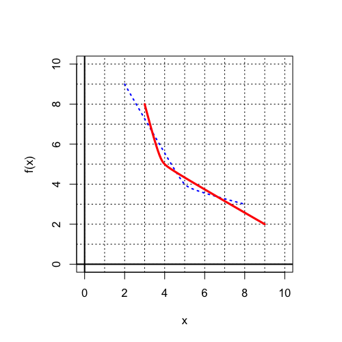

    - B

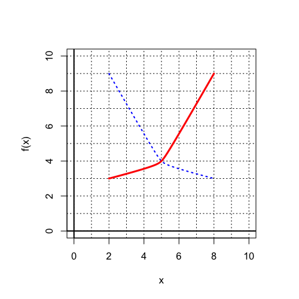

    - C

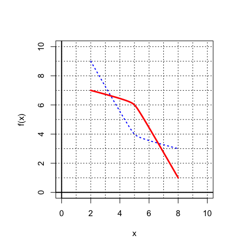

    - D

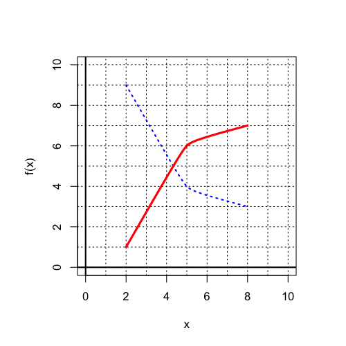

    1. A
    2. B
    3. C
    4. D

#### Solution

#### Question

45. The [one-to-one](https://en.wikipedia.org/wiki/Injective_function) function $f$ is plotted below:

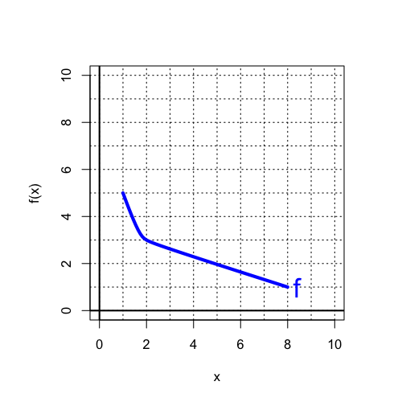

    Which of the following red curves is a graph of the inverse function, $f^{-1}$?
    - A

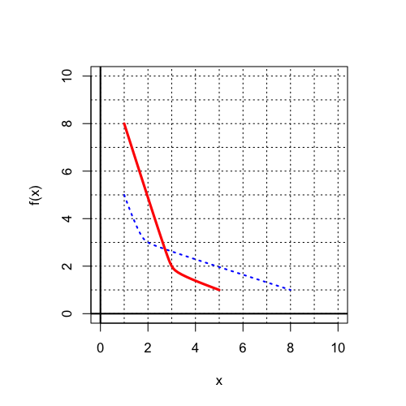

    - B

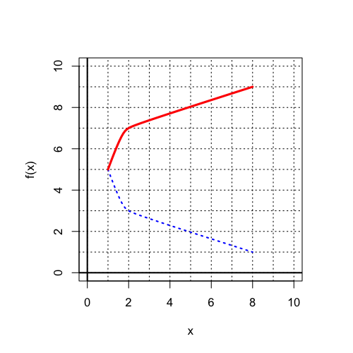

    - C

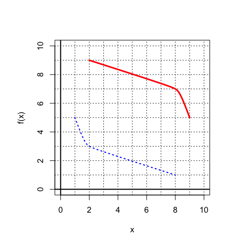

    - D

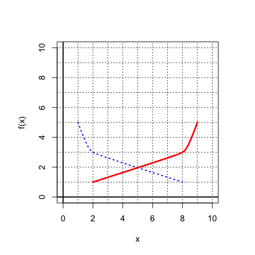

    1. A
    2. B
    3. C
    4. D

#### Solution

#### Question

46. The [one-to-one](https://en.wikipedia.org/wiki/Injective_function) function $f$ is plotted below:

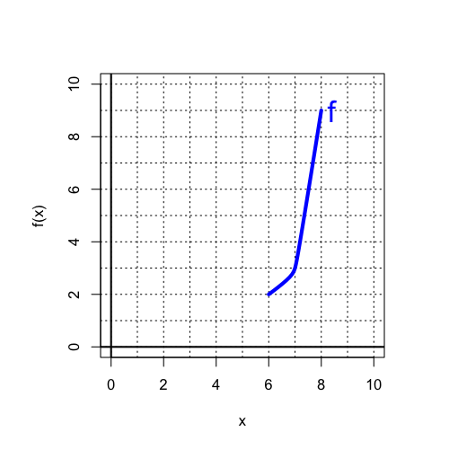

    Which of the following red curves is a graph of the inverse function, $f^{-1}$?
    - A

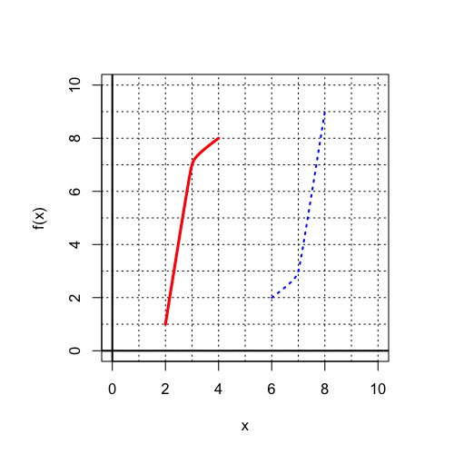

    - B

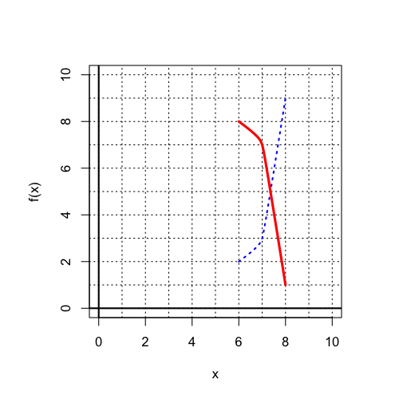

    - C

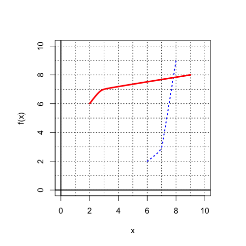

    - D

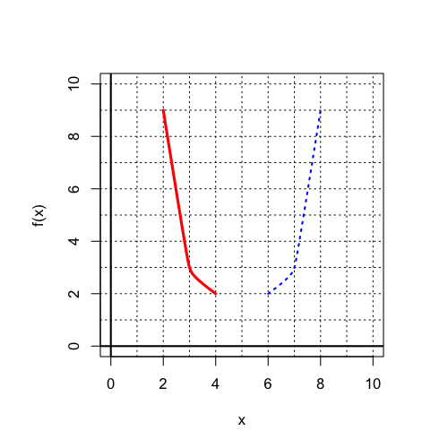

    1. A
    2. B
    3. C
    4. D

#### Solution

#### Question

47. The [one-to-one](https://en.wikipedia.org/wiki/Injective_function) function $f$ is plotted below:

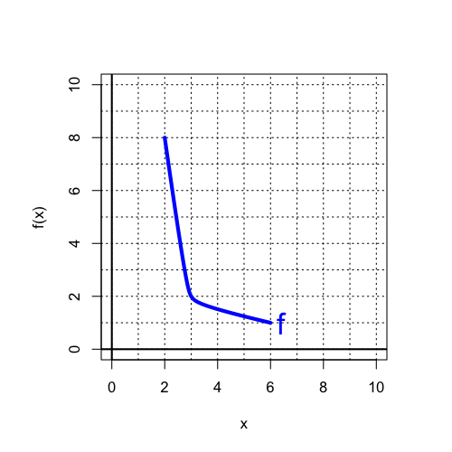

    Which of the following red curves is a graph of the inverse function, $f^{-1}$?
    - A

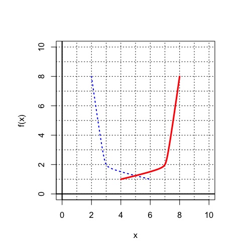

    - B

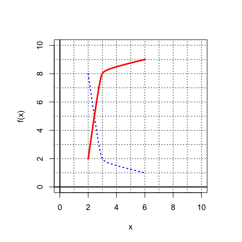

    - C

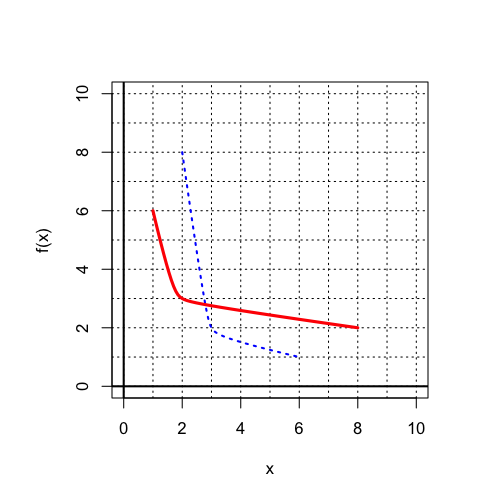

    - D

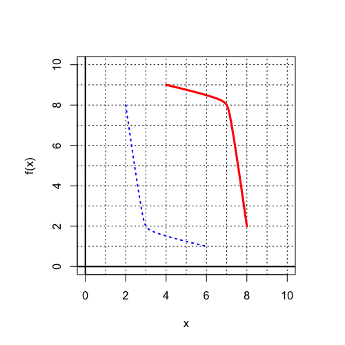

    1. A
    2. B
    3. C
    4. D

#### Solution

#### Question

48. The [one-to-one](https://en.wikipedia.org/wiki/Injective_function) function $f$ is plotted below:

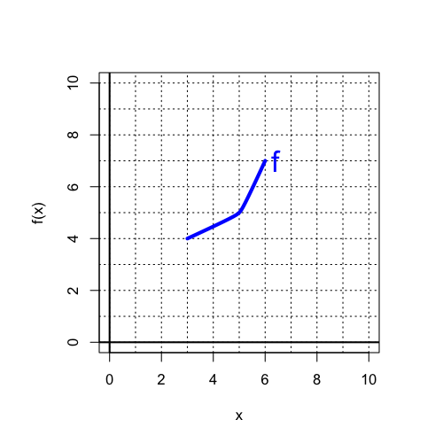

    Which of the following red curves is a graph of the inverse function, $f^{-1}$?
    - A

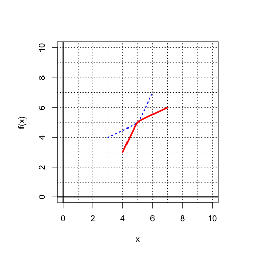

    - B

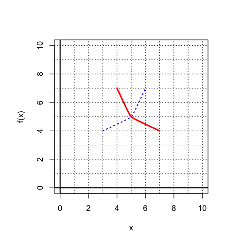

    - C

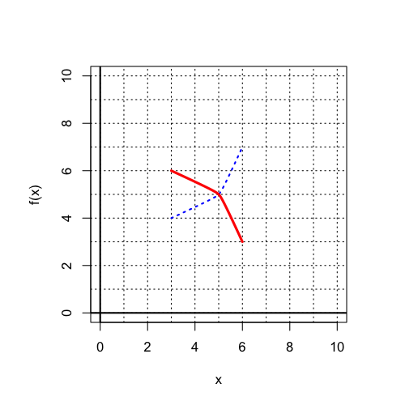

    - D

[figure not shown]

    1. A
    2. B
    3. C
    4. D

#### Solution

#### Question

49. The [one-to-one](https://en.wikipedia.org/wiki/Injective_function) function $f$ is plotted below:

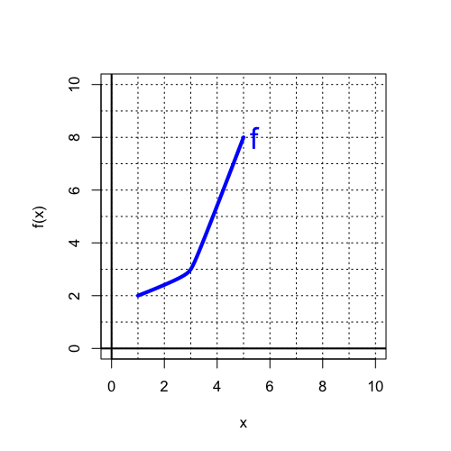

    Which of the following red curves is a graph of the inverse function, $f^{-1}$?
    - A

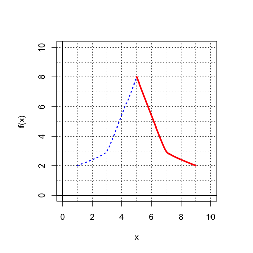

    - B

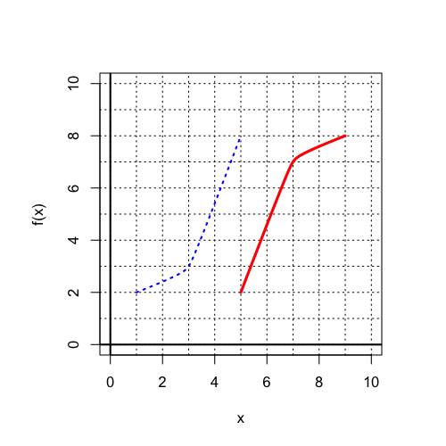

    - C

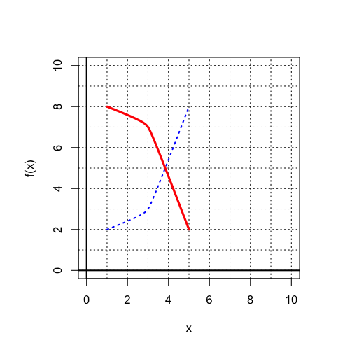

    - D

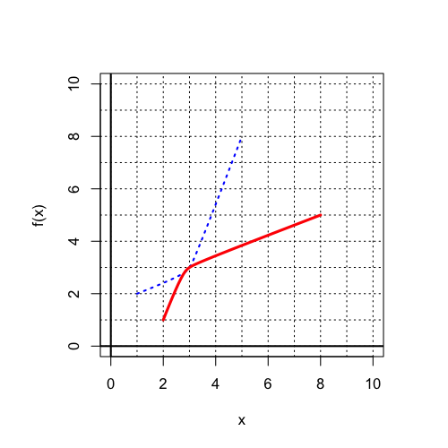

    1. A
    2. B
    3. C
    4. D

#### Solution

#### Question

50. The [one-to-one](https://en.wikipedia.org/wiki/Injective_function) function $f$ is plotted below:

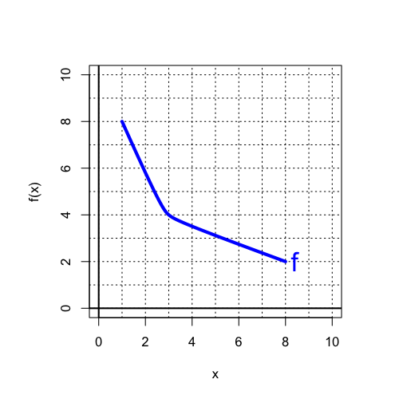

    Which of the following red curves is a graph of the inverse function, $f^{-1}$?
    - A

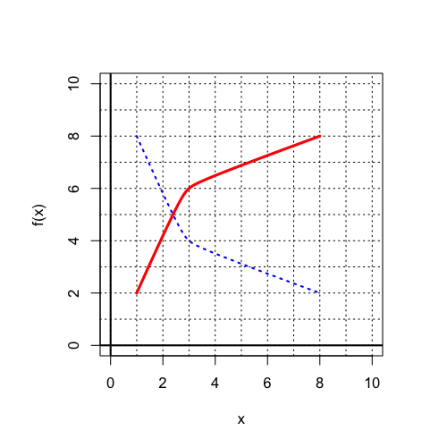

    - B

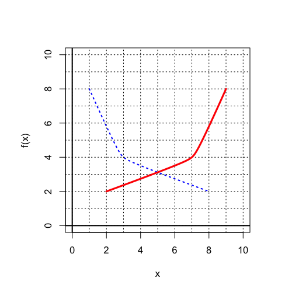

    - C

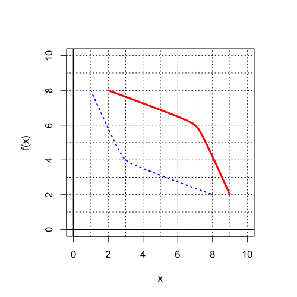

    - D

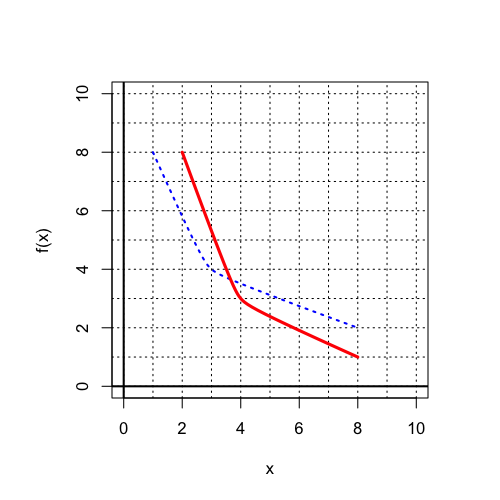

    1. A
    2. B
    3. C
    4. D

#### Solution

#### Question

51. This question asks you to find [one-sided limits](https://en.wikipedia.org/wiki/One-sided_limit).

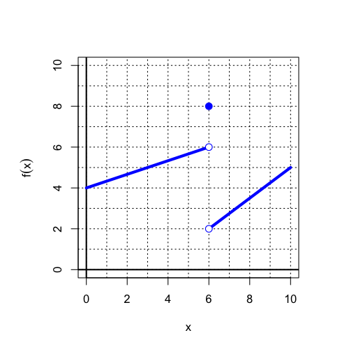

    - Find $f(6)$:
    - Find $\lim\limits_{x\to6^{-}}f(x)$:
    - Find $\lim\limits_{x\to6^{+}}f(x)$:

#### Solution

#### Question

52. This question asks you to find [one-sided limits](https://en.wikipedia.org/wiki/One-sided_limit).

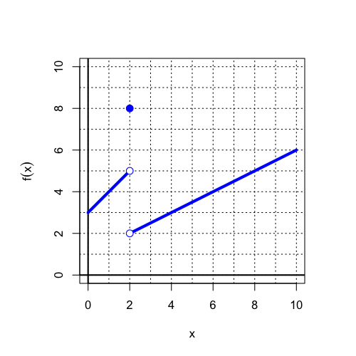

    - Find $f(2)$:
    - Find $\lim\limits_{x\to2^{-}}f(x)$:
    - Find $\lim\limits_{x\to2^{+}}f(x)$:

#### Solution

#### Question

53. This question asks you to find [one-sided limits](https://en.wikipedia.org/wiki/One-sided_limit).

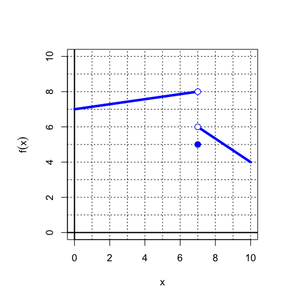

    - Find $f(7)$:
    - Find $\lim\limits_{x\to7^{-}}f(x)$:
    - Find $\lim\limits_{x\to7^{+}}f(x)$:

#### Solution

#### Question

54. This question asks you to find [one-sided limits](https://en.wikipedia.org/wiki/One-sided_limit).

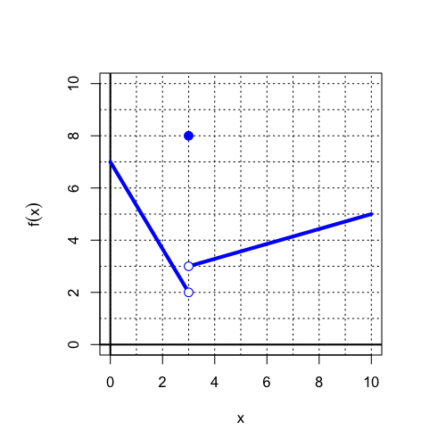

    - Find $f(3)$:
    - Find $\lim\limits_{x\to3^{-}}f(x)$:
    - Find $\lim\limits_{x\to3^{+}}f(x)$:

#### Solution

#### Question

55. This question asks you to find [one-sided limits](https://en.wikipedia.org/wiki/One-sided_limit).

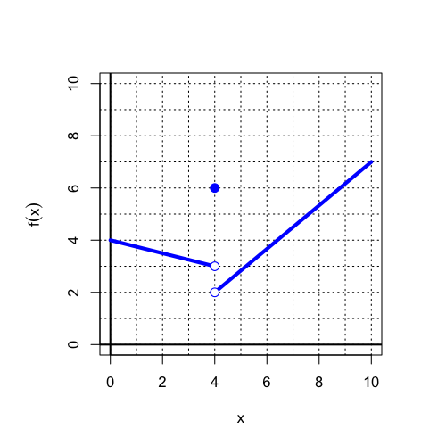

    - Find $f(4)$:
    - Find $\lim\limits_{x\to4^{-}}f(x)$:
    - Find $\lim\limits_{x\to4^{+}}f(x)$:

#### Solution

#### Question

56. This question asks you to find [one-sided limits](https://en.wikipedia.org/wiki/One-sided_limit).

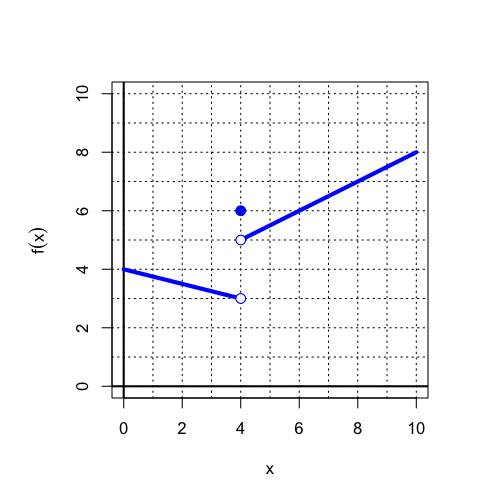

    - Find $f(4)$:
    - Find $\lim\limits_{x\to4^{-}}f(x)$:
    - Find $\lim\limits_{x\to4^{+}}f(x)$:

#### Solution

#### Question

57. This question asks you to find [one-sided limits](https://en.wikipedia.org/wiki/One-sided_limit).

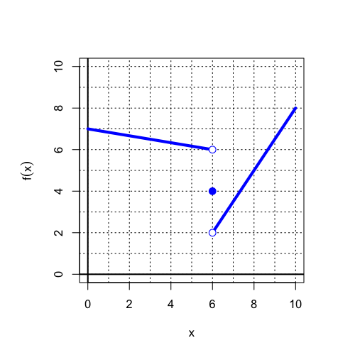

    - Find $f(6)$:
    - Find $\lim\limits_{x\to6^{-}}f(x)$:
    - Find $\lim\limits_{x\to6^{+}}f(x)$:

#### Solution

#### Question

58. This question asks you to find [one-sided limits](https://en.wikipedia.org/wiki/One-sided_limit).

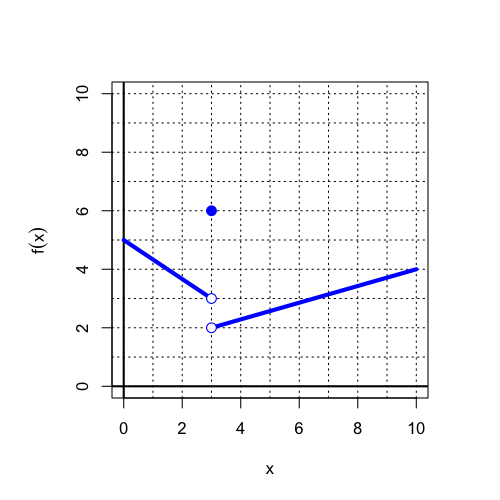

    - Find $f(3)$:
    - Find $\lim\limits_{x\to3^{-}}f(x)$:
    - Find $\lim\limits_{x\to3^{+}}f(x)$:

#### Solution

#### Question

59. This question asks you to find [one-sided limits](https://en.wikipedia.org/wiki/One-sided_limit).

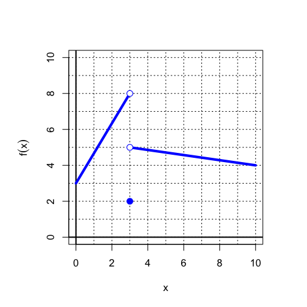

    - Find $f(3)$:
    - Find $\lim\limits_{x\to3^{-}}f(x)$:
    - Find $\lim\limits_{x\to3^{+}}f(x)$:

#### Solution

#### Question

60. This question asks you to find [one-sided limits](https://en.wikipedia.org/wiki/One-sided_limit).

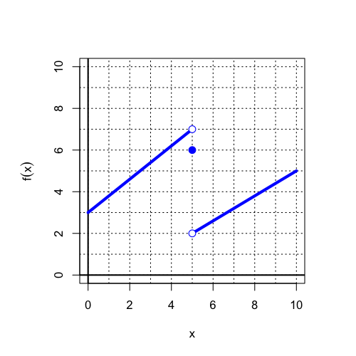

    - Find $f(5)$:
    - Find $\lim\limits_{x\to5^{-}}f(x)$:
    - Find $\lim\limits_{x\to5^{+}}f(x)$:

#### Solution

#### Question

61. Solve $x^{2} + 6 x + 5=0$ by factoring.
    1. -10
    2. -9
    3. -8
    4. -7
    5. -6
    6. -5
    7. -4
    8. -3
    9. -2
    10. -1
    11. 0
    12. 1
    13. 2
    14. 3
    15. 4
    16. 5
    17. 6
    18. 7
    19. 8
    20. 9
    21. 10

#### Solution

#### Question

62. Solve $x^{2} + 10 x + 24=0$ by factoring.
    1. -10
    2. -9
    3. -8
    4. -7
    5. -6
    6. -5
    7. -4
    8. -3
    9. -2
    10. -1
    11. 0
    12. 1
    13. 2
    14. 3
    15. 4
    16. 5
    17. 6
    18. 7
    19. 8
    20. 9
    21. 10

#### Solution

#### Question

63. Solve $x^{2} + 4 x + 3=0$ by factoring.
    1. -10
    2. -9
    3. -8
    4. -7
    5. -6
    6. -5
    7. -4
    8. -3
    9. -2
    10. -1
    11. 0
    12. 1
    13. 2
    14. 3
    15. 4
    16. 5
    17. 6
    18. 7
    19. 8
    20. 9
    21. 10

#### Solution

#### Question

64. Solve $x^{2} + 8 x + 15=0$ by factoring.
    1. -10
    2. -9
    3. -8
    4. -7
    5. -6
    6. -5
    7. -4
    8. -3
    9. -2
    10. -1
    11. 0
    12. 1
    13. 2
    14. 3
    15. 4
    16. 5
    17. 6
    18. 7
    19. 8
    20. 9
    21. 10

#### Solution

#### Question

65. Solve $x^{2} + 12 x + 35=0$ by factoring.
    1. -10
    2. -9
    3. -8
    4. -7
    5. -6
    6. -5
    7. -4
    8. -3
    9. -2
    10. -1
    11. 0
    12. 1
    13. 2
    14. 3
    15. 4
    16. 5
    17. 6
    18. 7
    19. 8
    20. 9
    21. 10

#### Solution

#### Question

66. Solve $x^{2} + 13 x + 40=0$ by factoring.
    1. -10
    2. -9
    3. -8
    4. -7
    5. -6
    6. -5
    7. -4
    8. -3
    9. -2
    10. -1
    11. 0
    12. 1
    13. 2
    14. 3
    15. 4
    16. 5
    17. 6
    18. 7
    19. 8
    20. 9
    21. 10

#### Solution

#### Question

67. Solve $x^{2} + 11 x + 24=0$ by factoring.
    1. -10
    2. -9
    3. -8
    4. -7
    5. -6
    6. -5
    7. -4
    8. -3
    9. -2
    10. -1
    11. 0
    12. 1
    13. 2
    14. 3
    15. 4
    16. 5
    17. 6
    18. 7
    19. 8
    20. 9
    21. 10

#### Solution

#### Question

68. Solve $x^{2} + 8 x + 7=0$ by factoring.
    1. -10
    2. -9
    3. -8
    4. -7
    5. -6
    6. -5
    7. -4
    8. -3
    9. -2
    10. -1
    11. 0
    12. 1
    13. 2
    14. 3
    15. 4
    16. 5
    17. 6
    18. 7
    19. 8
    20. 9
    21. 10

#### Solution

#### Question

69. Solve $x^{2} + 15 x + 56=0$ by factoring.
    1. -10
    2. -9
    3. -8
    4. -7
    5. -6
    6. -5
    7. -4
    8. -3
    9. -2
    10. -1
    11. 0
    12. 1
    13. 2
    14. 3
    15. 4
    16. 5
    17. 6
    18. 7
    19. 8
    20. 9
    21. 10

#### Solution

#### Question

70. Solve $x^{2} + 14 x + 48=0$ by factoring.
    1. -10
    2. -9
    3. -8
    4. -7
    5. -6
    6. -5
    7. -4
    8. -3
    9. -2
    10. -1
    11. 0
    12. 1
    13. 2
    14. 3
    15. 4
    16. 5
    17. 6
    18. 7
    19. 8
    20. 9
    21. 10

#### Solution

#### Question

71. Find $\lim\limits_{x\to2} \frac{x^2-x-2}{x^2+4x-12}$

    Enter your answer as a decimal. The tolerance is $\pm 0.01$.

#### Solution

#### Question

72. Find $\lim\limits_{x\to-5} \frac{x^2+8x+15}{x^2+13x+40}$

    Enter your answer as a decimal. The tolerance is $\pm 0.01$.

#### Solution

#### Question

73. Find $\lim\limits_{x\to1} \frac{x^2+6x-7}{x^2-3x+2}$

    Enter your answer as a decimal. The tolerance is $\pm 0.01$.

#### Solution

#### Question

74. Find $\lim\limits_{x\to-9} \frac{x^2+6x-27}{x^2+x-72}$

    Enter your answer as a decimal. The tolerance is $\pm 0.01$.

#### Solution

#### Question

75. Find $\lim\limits_{x\to-3} \frac{x^2+2x-3}{x^2+7x+12}$

    Enter your answer as a decimal. The tolerance is $\pm 0.01$.

#### Solution

#### Question

76. Find $\lim\limits_{x\to7} \frac{x^2+x-56}{x^2-3x-28}$

    Enter your answer as a decimal. The tolerance is $\pm 0.01$.

#### Solution

#### Question

77. Find $\lim\limits_{x\to4} \frac{x^2-x-12}{x^2+3x-28}$

    Enter your answer as a decimal. The tolerance is $\pm 0.01$.

#### Solution

#### Question

78. Find $\lim\limits_{x\to7} \frac{x^2-9x+14}{x^2-12x+35}$

    Enter your answer as a decimal. The tolerance is $\pm 0.01$.

#### Solution

#### Question

79. Find $\lim\limits_{x\to3} \frac{x^2+5x-24}{x^2-4x+3}$

    Enter your answer as a decimal. The tolerance is $\pm 0.01$.

#### Solution

#### Question

80. Find $\lim\limits_{x\to1} \frac{x^2+x-2}{x^2+7x-8}$

    Enter your answer as a decimal. The tolerance is $\pm 0.01$.

#### Solution